# Quantitative Comparison Report for Thunder Bay Art Gallery

[figure not shown]

# Introduction

This report has been provided to you to help you compare your charity’s key financial performance indicators against 9 other charities in the **Libraries, museums…** category. The financial data used in this report comes from the **2015** copy of the T3010 charity tax return. As such, the accuracy of the data and all indicators in this report is dependent on the information provided to Canada Revenue Agency by all registered charities. Therefore if there are any data quality issues, then I do not assume any responsibility for them.

The 9 other charities selected as comparators to your charity were the closest to your charity in terms of receipted + non-receipted donation total. In each section of this report you will find a table and an adjacent graph that enable you to compare your charity against the 9 others in terms of a variety of financial performance indicators. The indicator will be described at the beginning of each section and results are ordered by the value of the indicator.

# Section Links

Below please find links that will take you to different parts of this report:

Donation Total  
Cost of Administration per Dollar Raised  
Administrative Expense Percentage  
Fund-raising Cost per Dollar Raised  
Fund-raising Expense Percentage  
Overall Debt to Assets Ratio  
Funds Raised per Dollar Spent on Employee Compensation  
Government Revenue Percentage

# Donation Total

In **2015**, **Thunder Bay Art Gallery** reported a non-receipted donation total of **$47,382.00** and a receipted donation total of **$284,510.00**. Below are the 9 closest charities in the **Libraries, museums…** category in terms of overall donation total.

|  | Charity Name | Overall Donation Total |
| --- | --- | --- |
| 1 | Prince George Regional Art Gallery Association | 210177 |
| 2 | Shurniak Gallery Inc. | 250695 |
| 3 | Musee Des Beaux-Arts De Sherbrooke Inc | 272992 |
| 4 | Southern Alberta Art Gallery Association | 273876 |
| 5 | Museum Of Contemporary Canadian Art Corporation/Corporation Musee D'art Contemporain Canadien | 311039 |
| 6 | The Thunder Bay National Exhibition Centre And Centre For Indian Art | 331892 |
| 7 | Oakville Galleries | 358704 |
| 8 | Kamloops Art Gallery | 378834 |
| 9 | Le Musee Des Maitres Et Artisans Du Quebec | 389800 |
| 10 | Penticton Art Gallery Society | 412746 |

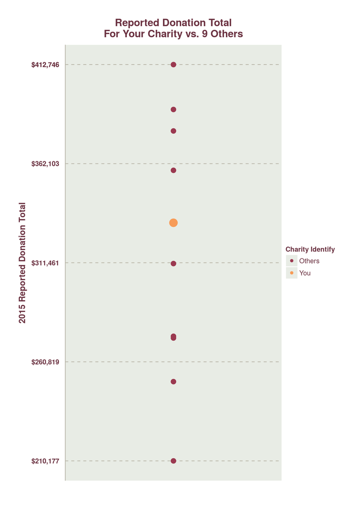

# Cost of Administration per Dollar Raised

In **2015**, **Thunder Bay Art Gallery** reported a total cost of management and administration of **$161,993**. When compared against the receipted + non-receipted donation total, **Thunder Bay Art Gallery** spent **$0.49** on administration for every dollar raised in **2015**. The table and graph below compare your charity against the same 9 other charities on the basis of administrative cost per dollar raised.

|  | Charity Name | Admin Cost per Dollar Raised |
| --- | --- | --- |
| 1 | Musee Des Beaux-Arts De Sherbrooke Inc | 0 |
| 2 | Shurniak Gallery Inc. | 0.0041006003310796 |
| 3 | Kamloops Art Gallery | 0.162498614168739 |
| 4 | Penticton Art Gallery Society | 0.258136965591429 |
| 5 | Le Musee Des Maitres Et Artisans Du Quebec | 0.404512570548999 |
| 6 | Oakville Galleries | 0.406742049154735 |
| 7 | The Thunder Bay National Exhibition Centre And Centre For Indian Art | 0.488089498993649 |
| 8 | Museum Of Contemporary Canadian Art Corporation/Corporation Musee D'art Contemporain Canadien | 0.590581888444857 |
| 9 | Prince George Regional Art Gallery Association | 1.62375997373642 |
| 10 | Southern Alberta Art Gallery Association | 2.03524952898392 |

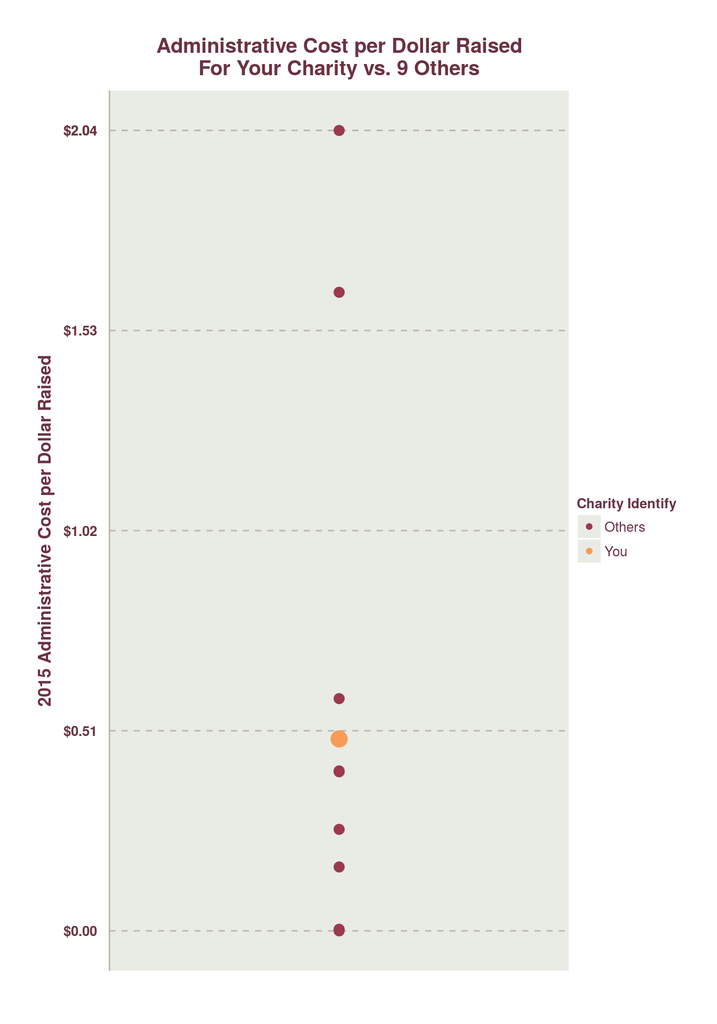

# Administrative Expense Percentage

In **2015**, **Thunder Bay Art Gallery** reported a total expenditure of **$1,036,044** on all aspects of the charity’s operation. Of this expenditure total, **15.64%** was spent on administrative expenses. The table and graph below compare your charity against the same 9 other charities on the basis of the ratio of administrative expenses to all expenditures.

|  | Charity Name | Admin Expense Percentage |
| --- | --- | --- |
| 1 | Musee Des Beaux-Arts De Sherbrooke Inc | 0 |
| 2 | Shurniak Gallery Inc. | 0.00370387718116211 |
| 3 | Kamloops Art Gallery | 0.0460904018759602 |
| 4 | Oakville Galleries | 0.129800459595047 |
| 5 | Museum Of Contemporary Canadian Art Corporation/Corporation Musee D'art Contemporain Canadien | 0.133098959446603 |
| 6 | Penticton Art Gallery Society | 0.148383718387771 |
| 7 | The Thunder Bay National Exhibition Centre And Centre For Indian Art | 0.156357258958114 |
| 8 | Le Musee Des Maitres Et Artisans Du Quebec | 0.181418103036655 |
| 9 | Prince George Regional Art Gallery Association | 0.227385207039089 |
| 10 | Southern Alberta Art Gallery Association | 0.457913337506593 |

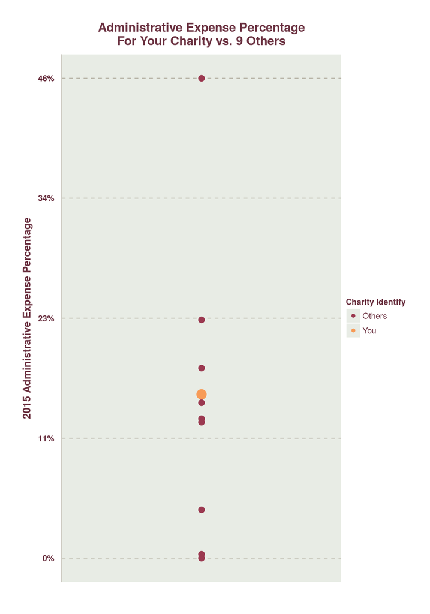

# Fund-raising Cost per Dollar Raised

In **2015**, **Thunder Bay Art Gallery** reported a total cost of fund-raising of **$867,083**. When compared against the receipted + non-receipted donation total, **Thunder Bay Art Gallery** spent **$2.61** on fund-raising for every dollar raised in **2015**. The table and graph below compare your charity against the same 9 other charities on the basis of fund-raising cost per dollar raised.

|  | Charity Name | Fund-raising Cost per Dollar Raised |
| --- | --- | --- |
| 1 | Musee Des Beaux-Arts De Sherbrooke Inc | 0 |
| 2 | Southern Alberta Art Gallery Association | 0.693423301055952 |
| 3 | Penticton Art Gallery Society | 0.811969104485567 |
| 4 | Shurniak Gallery Inc. | 1.10300963321965 |
| 5 | Le Musee Des Maitres Et Artisans Du Quebec | 1.14106464853771 |
| 6 | Museum Of Contemporary Canadian Art Corporation/Corporation Musee D'art Contemporain Canadien | 1.93215641768396 |
| 7 | Oakville Galleries | 2.11931843525581 |
| 8 | The Thunder Bay National Exhibition Centre And Centre For Indian Art | 2.61254564737927 |
| 9 | Kamloops Art Gallery | 3.27531847722221 |
| 10 | Prince George Regional Art Gallery Association | 4.88785642577447 |

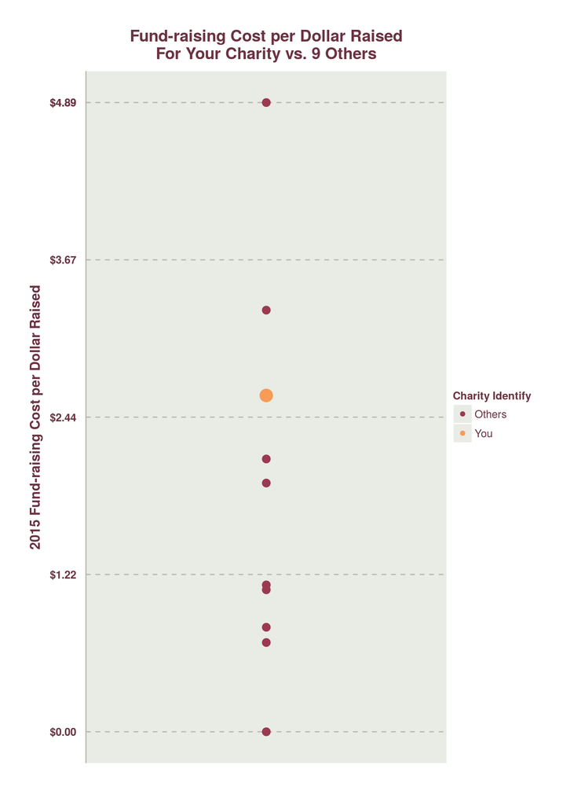

# Fund-raising Expense Percentage

In **2015**, **Thunder Bay Art Gallery** reported a total expenditure of **$1,036,044** on all aspects of the charity’s operation. Of this expenditure total, **83.69%** was spent on fund-raising expenses. The table and graph below compare your charity against the same 9 other charities on the basis of the ratio of fund-raising expenses to all expenditures.

|  | Charity Name | Fund-raising Expense Percentage |
| --- | --- | --- |
| 1 | Musee Des Beaux-Arts De Sherbrooke Inc | 0 |
| 2 | Southern Alberta Art Gallery Association | 0.156014175937381 |
| 3 | Museum Of Contemporary Canadian Art Corporation/Corporation Musee D'art Contemporain Canadien | 0.435448519017398 |
| 4 | Penticton Art Gallery Society | 0.466740571864681 |
| 5 | Le Musee Des Maitres Et Artisans Du Quebec | 0.511751176728447 |
| 6 | Oakville Galleries | 0.676321780588292 |
| 7 | Prince George Regional Art Gallery Association | 0.684476932138298 |
| 8 | The Thunder Bay National Exhibition Centre And Centre For Indian Art | 0.836917157958542 |
| 9 | Kamloops Art Gallery | 0.928997121970357 |
| 10 | Shurniak Gallery Inc. | 0.996296122818838 |

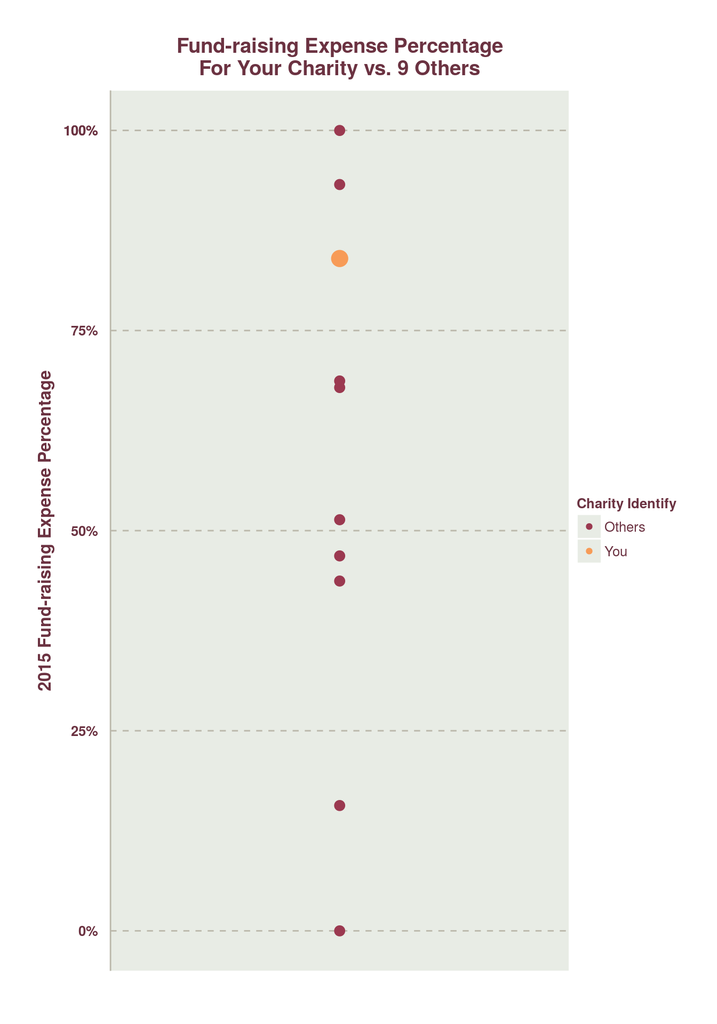

# Overall Debt to Assets Ratio

In **2015**, **Thunder Bay Art Gallery** reported total overall liabilities of **$173,841**. When compared against the reported total overall assets of **$668,857**, **Thunder Bay Art Gallery’s** debt to asset ratio is **25.99%**. The table and graph below compare your charity against the same 9 other charities on the basis of debt to assets ratio.

|  | Charity Name | Debt to Assets Ratio |
| --- | --- | --- |
| 1 | Penticton Art Gallery Society | 0.0150901276622169 |
| 2 | Shurniak Gallery Inc. | 0.0877788646751866 |
| 3 | Musee Des Beaux-Arts De Sherbrooke Inc | 0.184818720062576 |
| 4 | Museum Of Contemporary Canadian Art Corporation/Corporation Musee D'art Contemporain Canadien | 0.209436749219274 |
| 5 | Southern Alberta Art Gallery Association | 0.230698005772189 |
| 6 | The Thunder Bay National Exhibition Centre And Centre For Indian Art | 0.259907573666718 |
| 7 | Prince George Regional Art Gallery Association | 0.304326474488042 |
| 8 | Kamloops Art Gallery | 0.427140444954257 |
| 9 | Le Musee Des Maitres Et Artisans Du Quebec | 0.980227601198383 |
| 10 | Oakville Galleries | 1.21486394887189 |

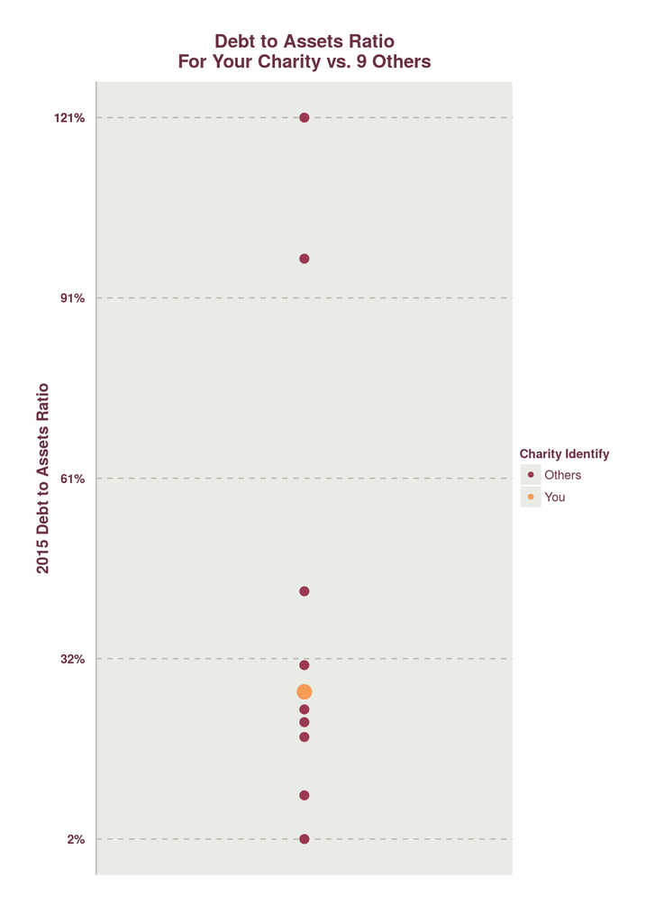

# Funds Raised per Dollar per Dollar Spent on Employee Compensation

In **2015**, **Thunder Bay Art Gallery** reported a total cost of employee compensation of **$445,769**. When the receipted + non-receipted donation total for your charity is compared against the cost of employee compensation, **Thunder Bay Art Gallery** raised **$0.74** for every dollar spent on employee compensation in **2015**. The table and graph below compare your charity against the same 9 other charities on the basis of funds raised per dollar of employee compensation.

|  | Charity Name | Funds Raised per Dollar of Employee Compensation |
| --- | --- | --- |
| 1 | Prince George Regional Art Gallery Association | 0.450572066191178 |
| 2 | Kamloops Art Gallery | 0.566734136084769 |
| 3 | Museum Of Contemporary Canadian Art Corporation/Corporation Musee D'art Contemporain Canadien | 0.582298837233248 |
| 4 | Oakville Galleries | 0.684967919340055 |
| 5 | Southern Alberta Art Gallery Association | 0.685864543029939 |
| 6 | The Thunder Bay National Exhibition Centre And Centre For Indian Art | 0.744538090356216 |
| 7 | Musee Des Beaux-Arts De Sherbrooke Inc | 1.0067672971747 |
| 8 | Le Musee Des Maitres Et Artisans Du Quebec | 1.1127350788449 |
| 9 | Penticton Art Gallery Society | 2.29881869371251 |
| 10 | Shurniak Gallery Inc. | 2.3875941675635 |

[figure not shown]

# Government Revenue Percentage

In **2015**, **Thunder Bay Art Gallery** reported a received total government revenue of **$0**. The amount received from the government represented, **0.00%** of all revenue reported by the charity. The table and graph below compare your charity against the same 9 other charities on the basis of the ratio of government revenue to all revenue. Please note that if none of the listed charities have reported any government revenue, then all values will be zero.

|  | Charity Name | Government Revenue Percentage |
| --- | --- | --- |
| 1 | The Thunder Bay National Exhibition Centre And Centre For Indian Art | 0 |
| 2 | Museum Of Contemporary Canadian Art Corporation/Corporation Musee D'art Contemporain Canadien | 0 |
| 3 | Oakville Galleries | 0 |
| 4 | Kamloops Art Gallery | 0 |
| 5 | Le Musee Des Maitres Et Artisans Du Quebec | 0 |
| 6 | Southern Alberta Art Gallery Association | 0 |
| 7 | Musee Des Beaux-Arts De Sherbrooke Inc | 0 |
| 8 | Penticton Art Gallery Society | 0 |
| 9 | Shurniak Gallery Inc. | 0 |
| 10 | Prince George Regional Art Gallery Association | 0 |

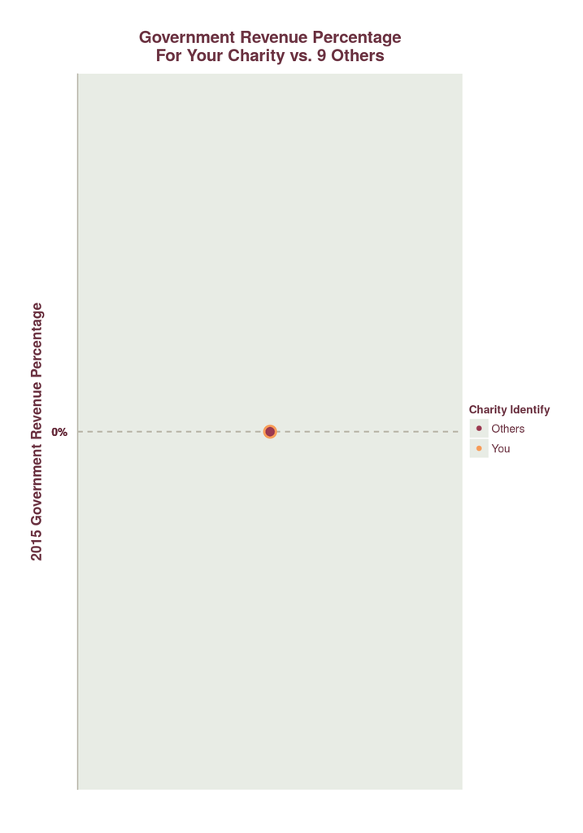